# New York Air Quality Measurements

# 1 New York Air Quality Measurements

## 1.1 Introduction

### 1.1.1 Description

Daily air quality measurements in New York, May to September 1973.

Usage airquality

#### 1.1.1.1 Format

A data frame with 153 observations on 6 variables.

[,1] Ozone numeric Ozone (ppb) [,2] Solar.R numeric Solar R (lang) [,3] Wind numeric Wind (mph) [,4] Temp numeric Temperature (degrees F) [,5] Month numeric Month (1–12) [,6] Day numeric Day of month (1–31)

#### 1.1.1.2 Details

- Daily readings of the following air quality values for May 1, 1973 (a Tuesday) to September 30, 1973.
- Ozone: Mean ozone in parts per billion from 1300 to 1500 hours at Roosevelt Island
- Solar.R: Solar radiation in Langleys in the frequency band 4000–7700 Angstroms from 0800 to 1200 hours at Central Park
- Wind: Average wind speed in miles per hour at 0700 and 1000 hours at LaGuardia Airport
- Temp: Maximum daily temperature in degrees Fahrenheit at La Guardia Airport.

## 1.2 Data Summary

```r
summary(airquality)
```

```
##      Ozone           Solar.R           Wind             Temp           Month
##  Min.   :  1.00   Min.   :  7.0   Min.   : 1.700   Min.   :56.00   Min.   :5.000
##  1st Qu.: 18.00   1st Qu.:115.8   1st Qu.: 7.400   1st Qu.:72.00   1st Qu.:6.000
##  Median : 31.50   Median :205.0   Median : 9.700   Median :79.00   Median :7.000
##  Mean   : 42.13   Mean   :185.9   Mean   : 9.958   Mean   :77.88   Mean   :6.993
##  3rd Qu.: 63.25   3rd Qu.:258.8   3rd Qu.:11.500   3rd Qu.:85.00   3rd Qu.:8.000
##  Max.   :168.00   Max.   :334.0   Max.   :20.700   Max.   :97.00   Max.   :9.000
##  NA's   :37       NA's   :7
##       Day
##  Min.   : 1.0
##  1st Qu.: 8.0
##  Median :16.0
##  Mean   :15.8
##  3rd Qu.:23.0
##  Max.   :31.0
##
```

## 1.3 Including Plots

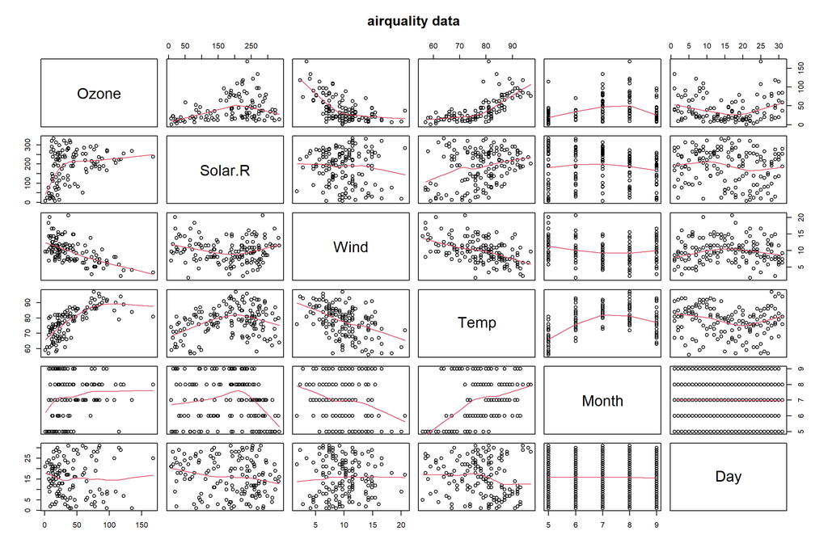

[output not shown]

[output cut: 123 more lines]

```r
require(graphics)
pairs(airquality, panel = panel.smooth, main = "airquality data")
```

# 2 Appendices

## 2.1 Source

### 2.1.1 Source

The data were obtained from the New York State Department of Conservation (ozone data) and the National Weather Service (meteorological data).

### 2.1.2 References

Chambers, J. M., Cleveland, W. S., Kleiner, B. and Tukey, P. A. (1983) Graphical Methods for Data Analysis. Belmont, CA: Wadsworth.